# Seattle mode share analysis for Comp Plan EIS

suzanne

2022-06-21

request- Ariel Davis, Fehr and Peers, on Behalf of city of Seattle

The City of Seattleis working on the comprehensive plan update EIS. We see that mode share data from the household travel survey is available at the citywide level online, but are looking to drill down to mode shares for the sectors shown below–which I realize may involve some additional work regarding weighting/sampling at those geographies.

The City set their targets based on the mode share of all trips that start or end in a sector for the weekday PM peak period. While it would be great to get data for the breakdown of all modes, their targets are just based on SOV/non-SOV so that would be the key number we’re looking for.

Other details from the call; looking at trip ends between sectors or with one end in a sector 3 pm- 6 pm All trips

If sample sizes are small, look all day

Could look at individual years

Start with SOV/Non-SOV see if you can get detailed modes

Background document: https://www.seattle.gov/Documents/Departments/OPCD/OngoingInitiatives/SeattlesComprehensivePlan/CouncilAdopted2020.pdf

The targets were developed with a mix of:

2014 Household Travel Survey estimates, the regional travel demand model (circa 2015), and a tool that estimate mode share reductions based on land use density, mix of uses, proximity to transit services, parking charges, and ped/bike infrastructure

## read in shape file with geographies

```r
library(sf)
library(dplyr)
```

```r
library(psrc.travelsurvey)
library(leaflet)
library(tidyr)
library(ggplot2)
library(raster)
library(ggspatial)
library(RColorBrewer)
library(lubridate)
library(scales)
```

Read in the Sector layer

```r
spn<- 2285
wgs_84<-4326

sectors_sea<-"C:/Users/SChildress/OneDrive - Puget Sound Regional Council/Documents/data_request/seattle_mode_share/SeattleSectors/SeattleSectors/Sectors.shp"

sector_layer<-st_read(sectors_sea)
sector_layer<- st_transform(sector_layer, crs=wgs_84)
```

Read in the travel survey data and do some work to clean up modes and times of day.

```r
mode_geo_df<-get_hhts('2017_2019', "t", vars= c('trip_id','main_mode', 'mode_simple', 'origin_lat', 'origin_lng', 'dest_lat', 'dest_lng', 'arrival_time_hhmm', 'depart_time_hhmm', 'travelers_total'))%>%
drop_na(c(origin_lat, dest_lat))%>%
mutate(mode_incl_hov = ifelse(mode_simple !='Drive', mode_simple, ifelse(travelers_total==1, 'SOV', 'HOV')))%>%
mutate(arrival_time = format(parse_date_time(arrival_time_hhmm, '%I:%M %p'), "%H"))%>%
mutate(depart_time = format(parse_date_time(depart_time_hhmm, '%I:%M %p'), "%H"))%>%
mutate(PM_Peak=ifelse(((arrival_time>=15 & arrival_time<18)|(depart_time>=15 & depart_time<18)), 'PM Peak', 'Not PM Peak'))
```

Turn the trip ends into a geographic data layer.

```r
mode_geo_sf_origin<-mode_geo_df%>% st_as_sf(coords=c("origin_lng","origin_lat"), crs= "+proj=longlat +datum=WGS84 +ellps=WGS84 +towgs84=0,0,0")
mode_geo_sf_dest<-mode_geo_df%>% st_as_sf(coords=c("dest_lng","dest_lat"), crs= "+proj=longlat +datum=WGS84 +ellps=WGS84 +towgs84=0,0,0")
```

Read in Seattle Sectors Layer

```r
sector_layer<-sector_layer%>%mutate(area=as.factor(area))
```

make a map of the sectors with the trip ends

```r
map.lat<-47.615
map.lon<--122.257
map.zoom<-10
pal <- leaflet::colorFactor(palette="Set2", domain = sector_layer$area)

travel_survey_map<- leaflet()%>%
     addProviderTiles(providers$CartoDB.Positron) %>%
  addLayersControl(baseGroups = c("Base Map"),
                      overlayGroups = c("Travel Survey Origins", "Seattle Sectors"),
                      options = layersControlOptions(collapsed = TRUE))%>%

  addPolygons(data=sector_layer,
               fillColor = pal(sector_layer$area),
               weight = 4,
               opacity = 0.1,
               color = "#91268F",
               dashArray = "4",
               fillOpacity = 1.0,
               group = "Seattle Sectors") %>%
     addCircles(data=mode_geo_sf_origin,
                  weight = .1,
                 radius = .1,
                  fill = TRUE,
                  opacity = 0.01,
                  group = ("Travel Survey Origins")) %>%

    leaflet::addLegend(pal = pal,
                       values = sector_layer$area,
                       position = "bottomright",
                       title = paste('Seattle Geo Sectors', '<br>', 'for Mode Share')) %>%

    leaflet::setView(lng=map.lon, lat=map.lat, zoom=map.zoom)
#travel_survey_map
```

Overlay the trip origins and destinations with the Seattle sectors so they can be put into them.

```r
sf::sf_use_s2(FALSE)
```

```
## Spherical geometry (s2) switched off
```

```r
origin_sector_sea<- st_join(mode_geo_sf_origin, sector_layer, join=st_within)
```

```
## although coordinates are longitude/latitude, st_within assumes that they are planar
```

```r
dest_sector_sea<-st_join(mode_geo_sf_dest,sector_layer, join=st_within)
```

```
## although coordinates are longitude/latitude, st_within assumes that they are planar
```

```r
origin_sector_sea<- as.data.frame(st_drop_geometry(origin_sector_sea))
dest_sector_sea<- as.data.frame(st_drop_geometry(dest_sector_sea))
```

```r
od_sector_sea<-merge(origin_sector_sea, dest_sector_sea, by='trip_id', suffixes=c('', '_dest'))%>% mutate(mode_nonm=ifelse((mode_incl_hov=='Walk' | mode_incl_hov=='Bike') , 'Non-Motorized', mode_incl_hov))
```

Summarize all trips by whether they are in the PM Peak, what mode they are, what Seattle sector the origin is in, and what Seattle sector the destination is in. Includes all times and places outside Seattle.

```r
trips_by_mode_PM<-hhts_count(od_sector_sea, group_vars=c('mode_nonm', 'PM_Peak', 'area', 'area_dest'), spec_wgt='trip_weight_2017_2019_v2021')
```

# This file will have all trips labelled with the origin area, destination area, and whether or not they are in the Peak. Includes trips outside of Seattle also

```r
#write.csv(trips_by_mode_PM, 'trips_by_mode_all.csv')
```

This analysis includes trips that originate or are destined to Seattle in the PM Peak. If the trip origin is in Seattle, it uses the origin of the trip as the Seattle trip end, otherwise it uses the destination end.

```r
trips_by_mode_PM_sea<-od_sector_sea%>%mutate(seattle_od=ifelse(is.na(area), as.character(area_dest), as.character(area)))%>%filter(PM_Peak=='PM Peak')

pm_trips_Seattle_origin_or_dest<-hhts_count(trips_by_mode_PM_sea, group_vars=c('seattle_od', 'mode_nonm') ,spec_wgt='trip_weight_2017_2019_v2021')%>%filter(mode_nonm!='Total')%>% filter(seattle_od!='Total')
```

```r
#write.csv(pm_trips_Seattle_origin_or_dest, 'trips_by_mode_pm_seattle_od.csv')
```

Make a chart to see how it looks

```r
create_facet_bar_chart <- function(t, w.x, w.y, g, w.scales="free", w.facet=3, d=0, w.factor=100, s="%", w.dec = 0, w.title, f, w.label=label_comma(),w.pos="dodge", lab.clr ="black", lab.sz=3) {

c <- ggplot(data=t,
aes(y=get(eval(w.y)),
x=get(eval(w.x)),
fill = get(eval(f)),
))+
geom_bar(position=w.pos, stat="identity") +
geom_text(aes(label = paste0(prettyNum(round(get(eval(w.y))*w.factor,w.dec), big.mark = ","),s)), vjust = -1.5, colour = lab.clr, size=lab.sz) +
scale_y_continuous(labels = w.label) +
theme_light() +
#scale_fill_manual(values=w.colors) +
theme(
axis.text.y= element_blank(),
axis.text.x= element_text(size = 8),
axis.title.y = element_blank(),
axis.title.x = element_blank(),
panel.grid.major.y = element_line(colour="#BBBDC0",size = 0.25),
panel.grid.major.x = element_blank(),
panel.grid.minor = element_blank(),
panel.border = element_blank(),
axis.line = element_blank(),
axis.ticks.x = element_blank(),
axis.ticks.y = element_blank(),
legend.position="right",
legend.title = element_blank())+
facet_wrap(vars(get(eval(g))), scales=w.scales, ncol=w.facet)+
scale_x_discrete(guide = guide_axis(n.dodge=3))

return(c)
}
```

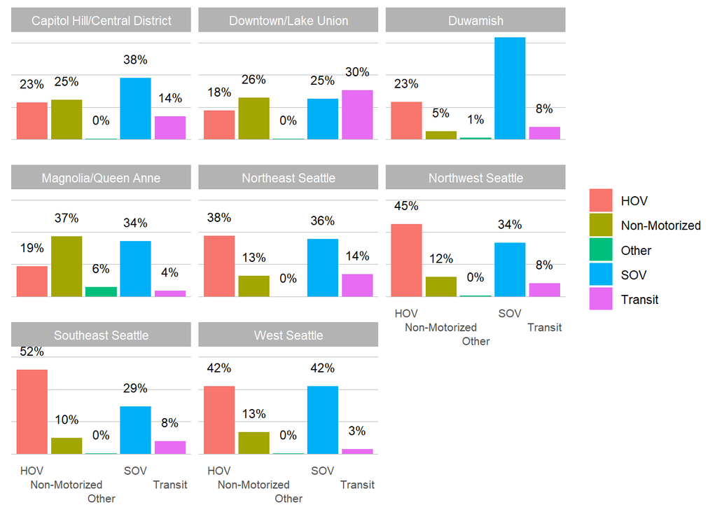

```r
create_facet_bar_chart(pm_trips_Seattle_origin_or_dest, w.x='mode_nonm', w.y='share', g='seattle_od', f='mode_nonm', w.scales='fixed')+theme(panel.spacing.y = unit(1, "lines"))
```

Recommended approach long term potentially? ## Use all Day travel for larger sample and to consider all people’s travel equally

Do not use PM Peak only because this is over-emphasizing the commute which is not equitable. We need emphasize all people not just commuters; we should consider travel at all times by all people this includes older adults, unemployed adults, and children. Also by using all day we eliminate the probably of assymmetry across origins and destinations by time because usually things are pretty symmetrical with trip ends and we can just use origins.

## Aggregate walk and bike for sample size

```r
od_sector_sea_only<- od_sector_sea %>% drop_na(area)%>%mutate(mode_dr_not=ifelse((mode_nonm=='SOV' | mode_nonm =='HOV'), 'Drive', 'Not Drive'))

all_day_trips_Seattle_origin<-hhts_count(od_sector_sea_only, group_vars=c('area', 'mode_dr_not' ),spec_wgt='trip_weight_2017_2019_v2021', incl_na=FALSE)%>%filter(mode_dr_not!='Total')
write.csv(all_day_trips_Seattle_origin,'all_day_trips_Seattle_origin.csv')
```

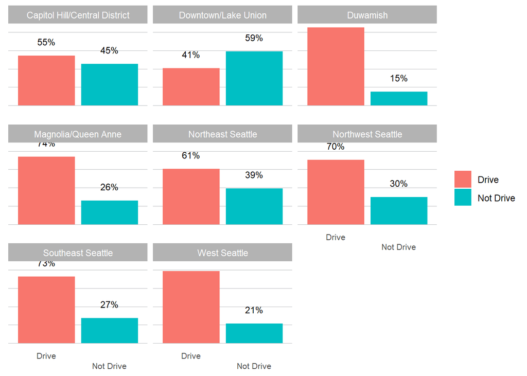

```r
create_facet_bar_chart(all_day_trips_Seattle_origin, w.x='mode_dr_not', w.y='share', g='area', f='mode_dr_not', w.scales='fixed')+theme(panel.spacing.y = unit(1, "lines"))
```